# Wielowymiarowa Analiza Rezerwacji Hotelowych

# 1. Wprowadzenie

## 1.1. Motywacja i cel pracy

Rezerwacje hotelowe są integralną częścią branży turystycznej i hotelarskiej, która dynamicznie się rozwija i w której decyzje biznesowe w dużej mierze opierają się na danych. Każdego dnia hotele przyjmują setki, a nawet tysiące gości, a systemy rezerwacyjne gromadzą szczegółowe informacje o czasie dokonania rezerwacji, liczbie osób, długości pobytu, typie hotelu czy dodatkowych usługach. Choć dane te są dostępne, rzadko analizuje się je kompleksowo, aby zrozumieć wzorce zachowań klientów i czynniki wpływające na anulowanie rezerwacji.

Zbiór danych o rezerwacjach hotelowych zawiera wiele powiązanych ze sobą zmiennych, takich jak typ hotelu, czas oczekiwania na przyjazd, liczba dorosłych i dzieci, sezonowość, liczba wcześniejszych anulacji czy liczba specjalnych próśb. Ponieważ cech jest wiele i mogą one wpływać na siebie nawzajem, trudno jest je analizować pojedynczo. Dlatego w projekcie zastosowano metody wielowymiarowej analizy danych, które pozwalają zidentyfikować najważniejsze zależności i wzorce w zbiorze danych.

Celem projektu jest lepsze zrozumienie zachowań klientów hotelowych, identyfikacja czynników wpływających na anulowanie rezerwacji oraz wykrycie naturalnych grup rezerwacji, które różnią się między sobą pod względem charakterystyki gości i wzorców pobytu. W tym celu wykorzystano m.in. analizę głównych składowych (PCA), metody klasteryzacji oraz inne techniki eksploracyjne, które pomagają uporządkować dane i wydobyć najważniejsze informacje.

**Główne cele projektu to:**

- zbadanie zależności między różnymi cechami rezerwacji hotelowych,
- identyfikacja zmiennych, które najbardziej wpływają na anulowanie rezerwacji,
- zastosowanie PCA do redukcji wymiarowości i interpretacji składowych,
- wykrycie naturalnych grup rezerwacji przy użyciu metod analizy skupień (klastrów),
- ocena przydatności zastosowanych metod w analizie danych hotelowych i podejmowaniu decyzji biznesowych.

## 1.2. Opis problemu badawczego

Powyżej przedstawiono ogólny kontekst problemu związanego z rezerwacjami hotelowymi. Zbiór danych zawiera wiele zmiennych opisujących rezerwacje – zarówno cechy gości, jak i szczegóły dotyczące pobytu czy anulowania rezerwacji. Ich wzajemne powiązania są złożone i trudne do analizy bez zastosowania odpowiednich metod statystycznych i eksploracyjnych.

W związku z tym w projekcie należy odpowiedzieć na kilka kluczowych pytań badawczych:

- Które cechy rezerwacji (np. czas oczekiwania na przyjazd, liczba osób, typ hotelu) są ze sobą najsilniej powiązane?
- Które zmienne mają największy wpływ na anulowanie rezerwacji?
- Czy można zidentyfikować naturalne grupy rezerwacji, np. według charakterystyki gości, typu hotelu lub wzorców pobytu?
- Czy zastosowanie metod redukcji wymiarowości (np. PCA) pozwala lepiej zrozumieć strukturę danych i ułatwia interpretację powiązań między zmiennymi?

## 1.3. Opis danych

Dane wykorzystane w projekcie pochodzą z publicznego repozytorium Kaggle i są dostępne pod adresem https://www.kaggle.com/datasets/mojtaba142/hotel-booking. Zbiór obejmuje rezerwacje dokonane w dwóch typach hoteli – city hotel i resort hotel – w okresie od lipca 2015 do sierpnia 2017. Dane są kompletne, liczne i dobrze przystosowane do analiz wielowymiarowych.

Jako **zmienną objaśnianą** przyjęto zmienną *is_canceled*, która wskazuje, czy rezerwacja została anulowana. Pozostałe zmienne ilościowe i kategoryczne podzielono na grupy w zależności od ich potencjalnego wpływu na ryzyko anulowania rezerwacji, co pozwala badać zarówno czynniki stymulujące, jak i hamujące rezerwacje.

**Struktura zbioru:**

- liczba obserwacji: 119 390
- liczba zmiennych: 36

*Zmienna objaśniana:*

- *is_canceled*

Zmienna objaśniana została wyszczególniona w celu ułatwienia analizy rozkładów i zależności korelacyjnych. Jako główny wskaźnik analizowanego zjawiska umożliwia ocenę wpływu pozostałych zmiennych na jej wartości oraz identyfikację czynników odpowiadających za obserwowane zróżnicowanie danych. W dalszej części analizy odstąpiono od podziału na zmienną objaśnianą i objaśniające, ponieważ zastosowane metody (PCA oraz klasteryzacja) mają charakter eksploracyjny i służą identyfikacji struktury oraz zależności pomiędzy wszystkimi zmiennymi jednocześnie.

*Zmienne objaśniające:*

*Stymulanty* - ich wzrost zmniejsza prawdopodobieństwo anulowania pobytu:

1. previous_bookings_not_canceled → lojalność klienta,
2. is_repeated_guest → lojalność klienta,
3. total_of_special_requests → większe zaangażowanie klienta,
4. stays_in_weekend_nights → dłuższy pobyt → mniejsza szansa anulowania,
5. stays_in_week_nights → dłuższy pobyt → mniejsza szansa anulowania,
6. adults → rezerwacje rodzinne są stabilniejsze,
7. children → rezerwacje rodzinne są stabilniejsze,
8. babies → rezerwacje rodzinne są stabilniejsze,
9. required_car_parking_spaces → klient raczej planuje przyjazd.

*Destymulanty* - ich wzrost zwiększa ryzyko anulowania:

10. lead_time → im wcześniej rezerwacja, tym większa szansa anulowania,
11. previous_cancellations → historia anulowań,
12. booking_changes → niestabilność rezerwacji,
13. days_in_waiting_list → niepewność dostępności,
14. adr (średnia cena za noc) → droższe rezerwacje częściej anulowane.

*Nominanty* - świetnie nadają się do kodowania, mogą wejść do PCA (po kodowaniu) lub klasteryzacji

15. arrival_date_month,
16. arrival_date_week_number,
17. hotel (City / Resort),
18. market_segment,
19. distribution_channel,
20. meal,
21. country,
22. reserved_room_type,
23. assigned_room_type,
24. deposit_type,
25. customer_type.

*Pozostałe zmienne* i ich zastosowanie analityczne w projekcie

- **arrival_date_year**, **arrival_date_day_of_month** → zmienne czasowe, które można jedynie wykorzystać do analizy kontekstowej oraz tworzenia nowych cech;
- **reservation_status**, **reservation_status_date** → zmienne opisujące status rezerwacji są bezpośrednio powiazane ze zmienną objaśniającą; zostały wykluczone z modelowania, aby uniknąć wycieku informacji (data leakage);
- **agent**, **company**, **name**, **email**, **phone.number**, **credit_card** → zmienne identyfikujące o braku interpretacji ekonomicznej i istotności analitycznej, zawierają bardzo dużo kategorii, przez co mogą zdominować PCA; zostały wykluczone z modelowania, ale zostają do opisu danych.

| zmienna | typ_danych | stymulanta_destymulanta |
| --- | --- | --- |
| odwołanie_rezerwacji | integer | zmienna objaśniana |
| liczba_dorosłych | integer | stymulanta |
| liczba_dzieci | numeric | stymulanta |
| liczba_niemowląt | integer | stymulanta |
| liczba_nocy_tygodniowych | integer | stymulanta |
| liczba_nocy_weekendowych | integer | stymulanta |
| liczba_specjalnych_próśb | integer | stymulanta |
| powracający_gość | integer | stymulanta |
| wcześniejsze_rezerwacje_nieodwołane | integer | stymulanta |
| wymagane_miejsca_parkingowe | integer | stymulanta |

[output cut: 26 more lines]

## 1.4. Identyfikacja zmiennych binarnych

| Zmienne binarne: |
| --- |
| odwołanie_rezerwacji, powracający_gość |

W zbiorze pznajdują się dwie zmienne binarne: zmienna objaśniana - *odwołanie_rezerwacji* oraz zmienna objaśniająca *powracający_gość*.

# 2. Analiza eksploracyjna danych

## 2.1. Podstawowe statystyki opisowe

| zmienna | min | max | średnia | sd | Q1 | mediana | Q3 |
| --- | --- | --- | --- | --- | --- | --- | --- |
| wcześniejsze_rezerwacje_nieodwołane | 0 | 72 | 0.14 | 1.5 | 0 | 0 | 0 |
| liczba_specjalnych_próśb | 0 | 5 | 0.57 | 0.79 | 0 | 0 | 1 |
| liczba_nocy_weekendowych | 0 | 19 | 0.93 | 1 | 0 | 1 | 2 |
| liczba_nocy_tygodniowych | 0 | 50 | 2.5 | 1.91 | 1 | 2 | 3 |
| liczba_dorosłych | 0 | 55 | 1.86 | 0.58 | 2 | 2 | 2 |
| liczba_dzieci | 0 | 10 | 0.1 | 0.4 | 0 | 0 | 0 |
| liczba_niemowląt | 0 | 10 | 0.01 | 0.1 | 0 | 0 | 0 |
| wymagane_miejsca_parkingowe | 0 | 8 | 0.06 | 0.25 | 0 | 0 | 0 |
| czas_wyprzedzenia_rezerwacji | 0 | 737 | 104.01 | 106.86 | 18 | 69 | 160 |
| wcześniejsze_odwołania | 0 | 26 | 0.09 | 0.84 | 0 | 0 | 0 |

[output cut: 3 more lines]

| zmienna | min | max | średnia | sd | Procent_1 |
| --- | --- | --- | --- | --- | --- |
| odwołanie_rezerwacji | 0 | 1 | 0.37 | 0.48 | 37.04% |
| powracający_gość | 0 | 1 | 0.03 | 0.18 | 3.19% |

| zmienna | Top1 | %_Top1 | Top2 | %_Top2 | Top3 | %_Top3 |
| --- | --- | --- | --- | --- | --- | --- |
| typ_hotelu | City Hotel | 66.4% | Resort Hotel | 33.5% |  |  |
| rodzaj_wyżywienia | BB | 77.3% | HB | 12.1% | SC | 8.9% |
| segment_rynku | Online TA | 47.3% | Offline TA/TO | 20.3% | Groups | 16.6% |
| kanał_dystrybucji | TA/TO | 82% | Direct | 12.3% | Corporate | 5.6% |
| rodzaj_zarezerwowanego_pokoju | A | 72% | D | 16.1% | E | 5.5% |
| rodzaj_przydzielonego_pokoju | A | 62% | D | 21.2% | E | 6.5% |
| rodzaj_depozytu | No Deposit | 87.7% | Non Refund | 12.2% | Refundable | 0.1% |
| typ_klienta | Transient | 75.1% | Transient-Party | 21% | Contract | 3.4% |
| miesiąc_przyjazdu | August | 11.6% | July | 10.6% | May | 9.9% |
| numer_tygodnia_przyjazdu | 33 | 3% | 30 | 2.6% | 32 | 2.5% |

[output cut: 3 more lines]

Przeprowadzono analizę statystyczną zmiennych ilościowych, binarnych oraz kategorycznych.

**Zmienne ilościowe** opisano za pomocą następujących statystyk: wartość minimalna i maksymalna, średnia, odchylenie standardowe oraz kwantyle 1, 2 (mediana) i 3. Niepokojąca jest ujemna wartość *średniej ceny za noc*, którą poddano dodatkowej analizie w kolejnych etapach przetwarzania danych.

W zbiorze znajdują się również dwie **zmienne binarne**: zmienna objaśniana *odwołanie_rezerwacji* oraz zmienna objaśniająca *powracający_gość*. Kolumna Procent_1 przedstawia odsetek obserwacji, w których zmienna przyjmuje wartość 1. Rezerwację odwołało niecałe 38% gości, a zaledwie 3,19% odwiedzających powraca do tego hotelu.

**Zmienne kategoryczne** opisano pod względem najczęściej występujących wartości wraz z ich udziałem w całym zbiorze.

## 2.2. Analiza rozkładów

### 2.2.1. Histogramy dla zmiennych ilościowych w postaci logarytmicznej

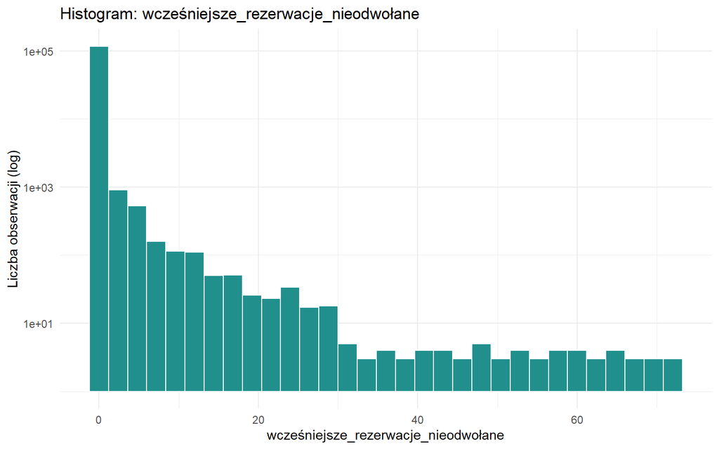

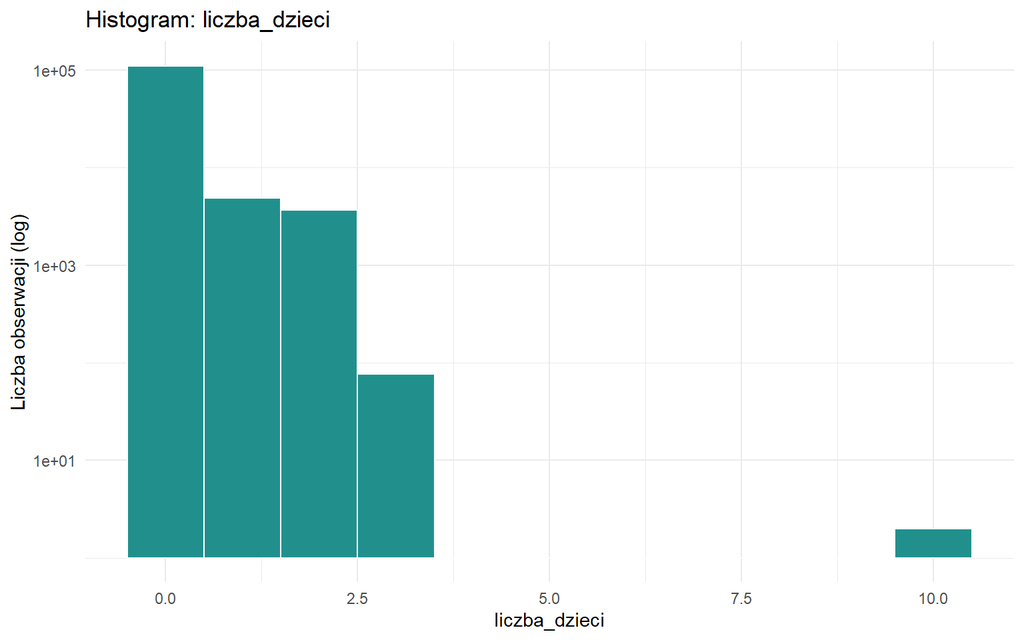

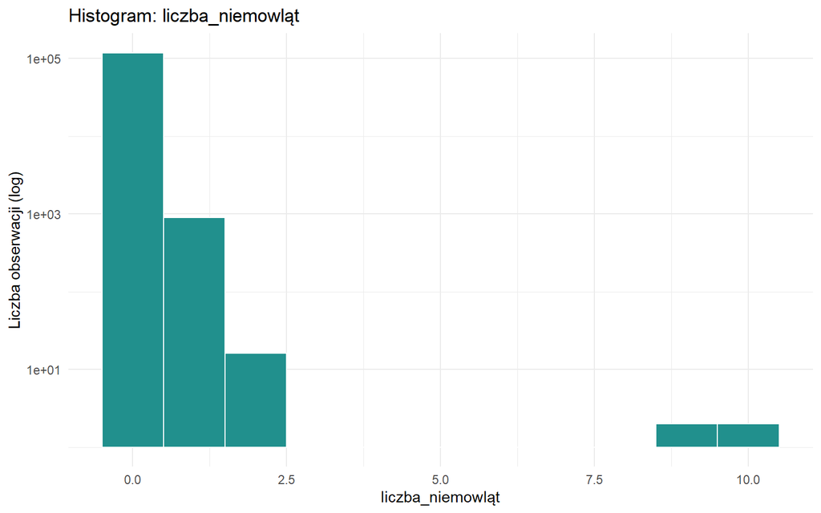

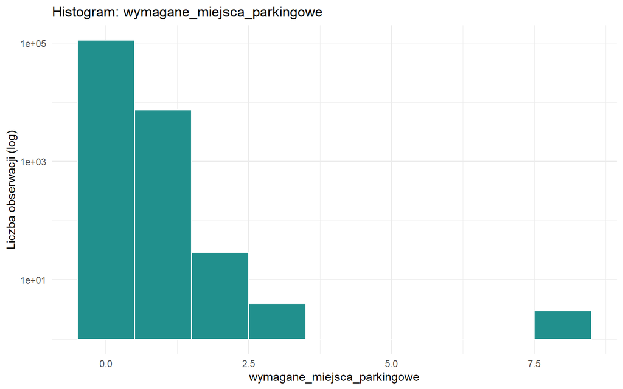

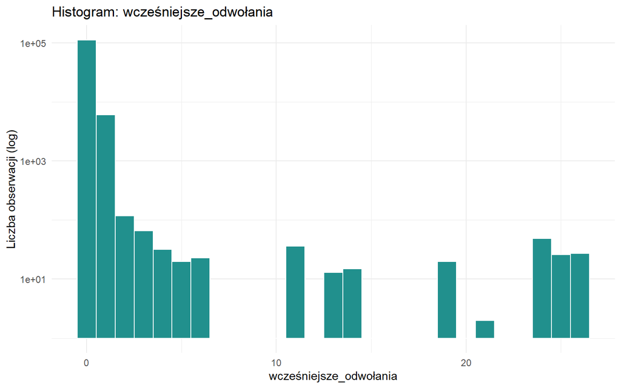

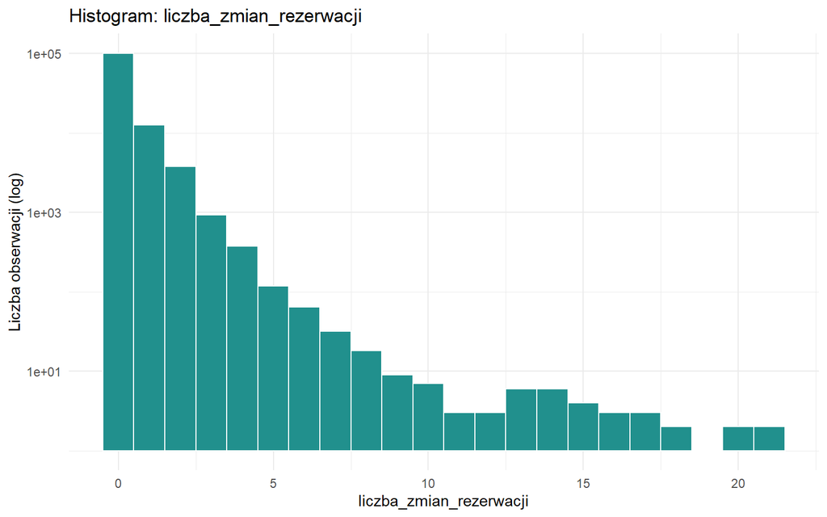

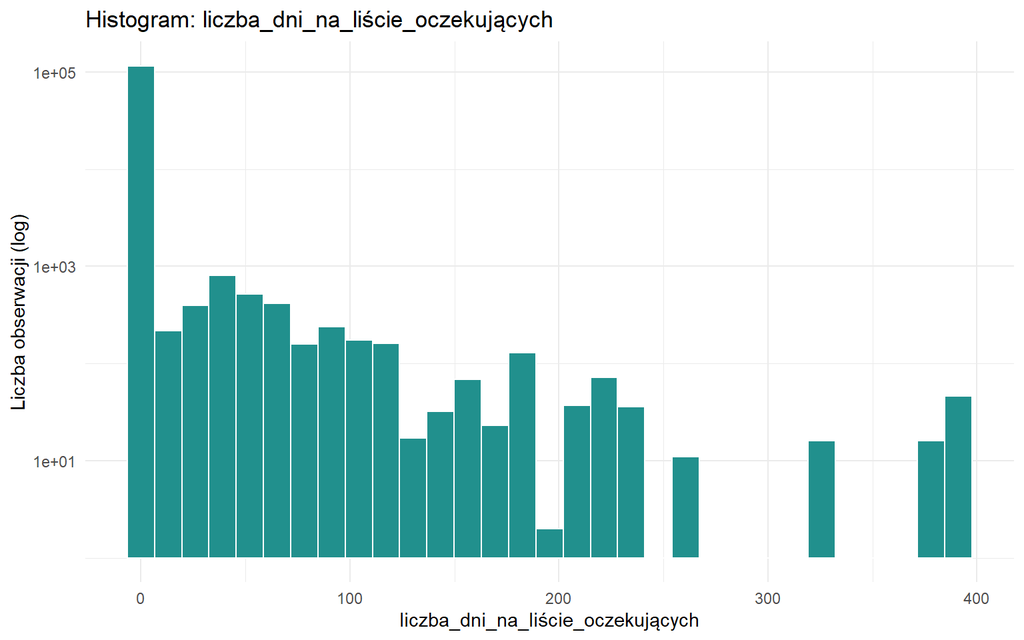

Histogramy **zmiennych ilościowych** zaprezentowano z wykorzystaniem logarytmicznej osi OY, co pozwoliło odsłonić strukturę rozkładów niewidoczną przy klasycznej skali. Wynika to z faktu, że we wszystkich przypadkach zdecydowanie dominuje wartość „0”, skutecznie maskująca zróżnicowanie pozostałych obserwacji.

### 2.2.2. Histogramy dla pozostałych zmiennych ilościowych

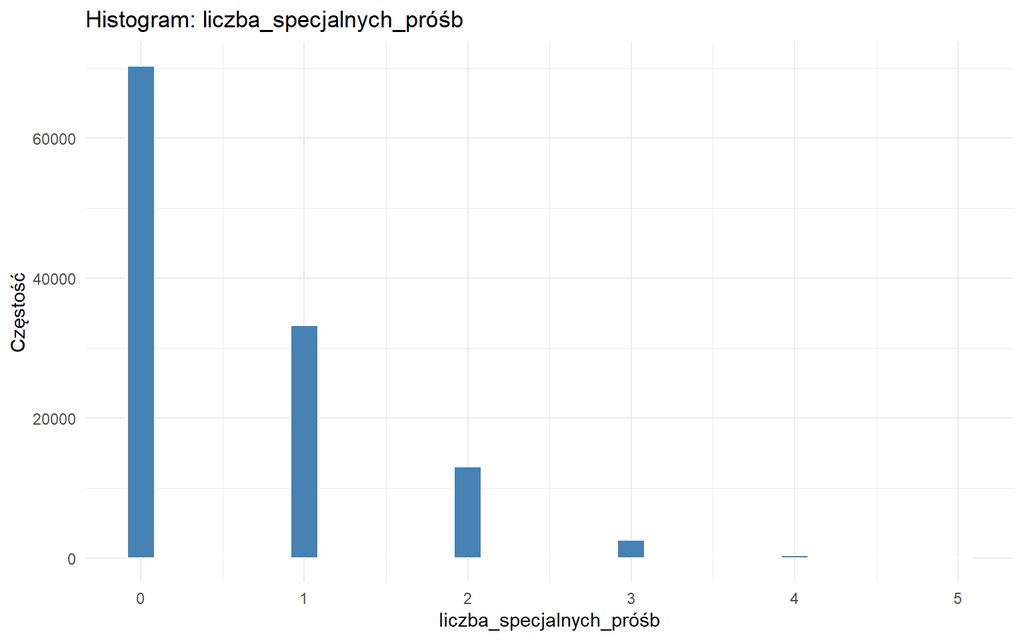

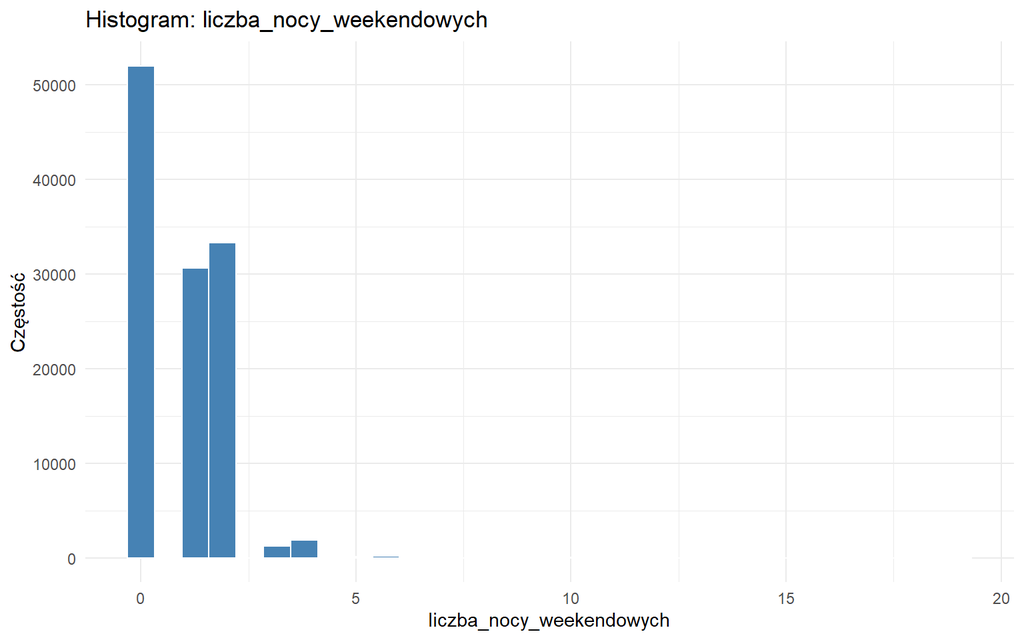

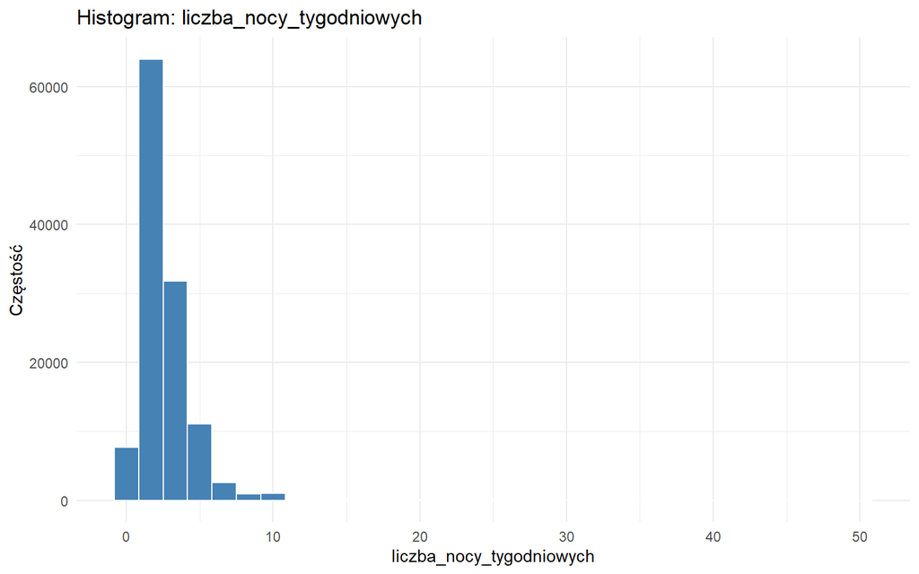

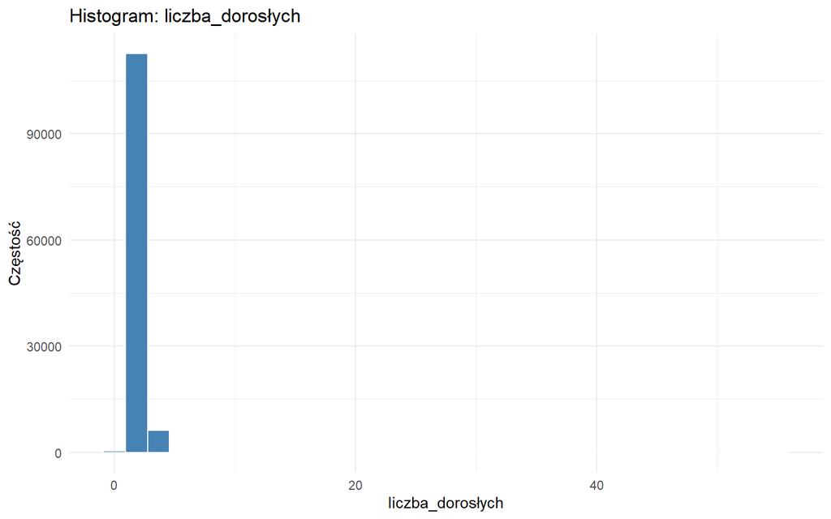

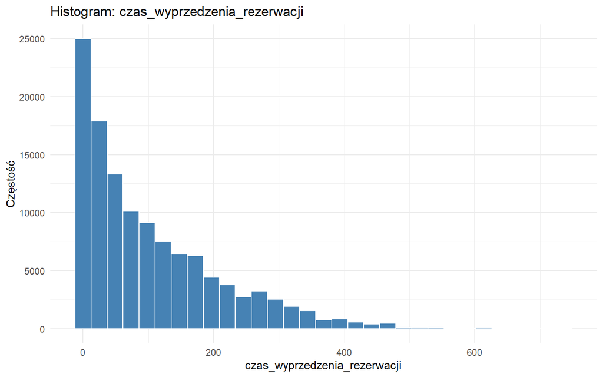

### 2.2.3. Histogramy dla zmiennych kategorycznych

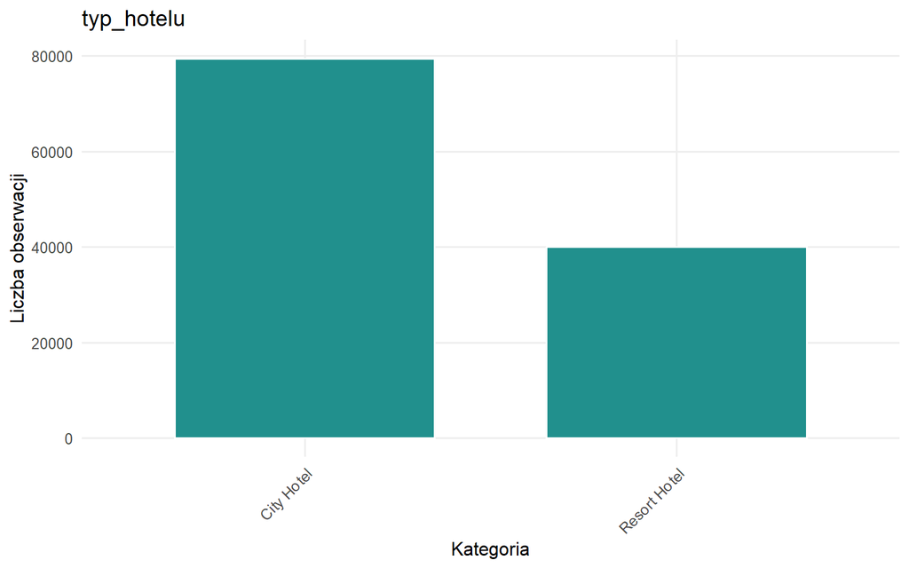

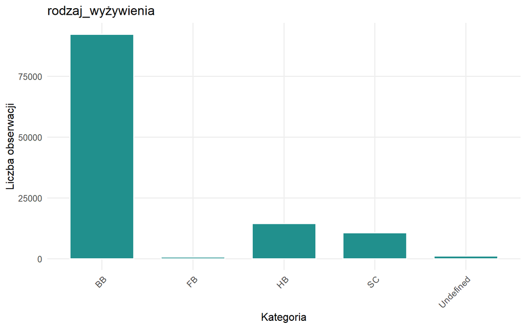

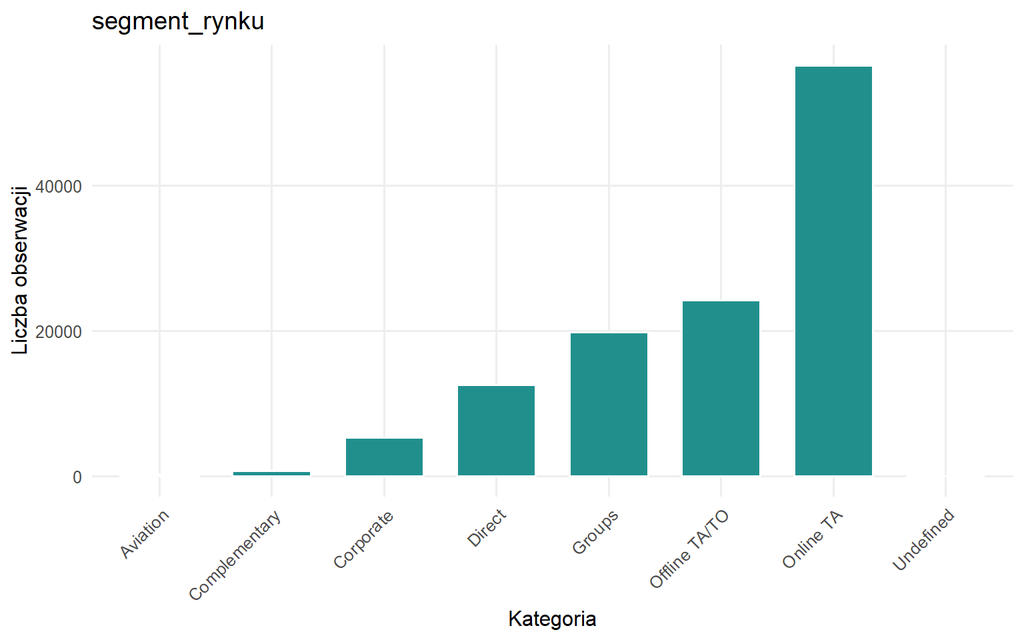

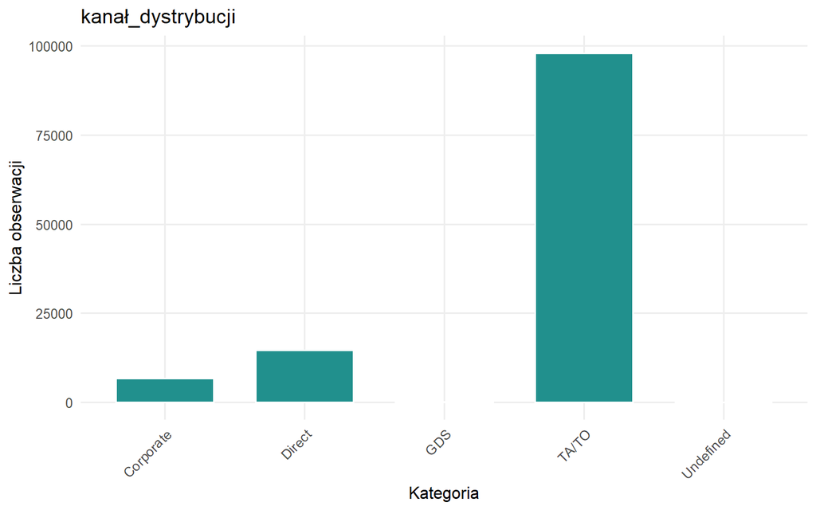

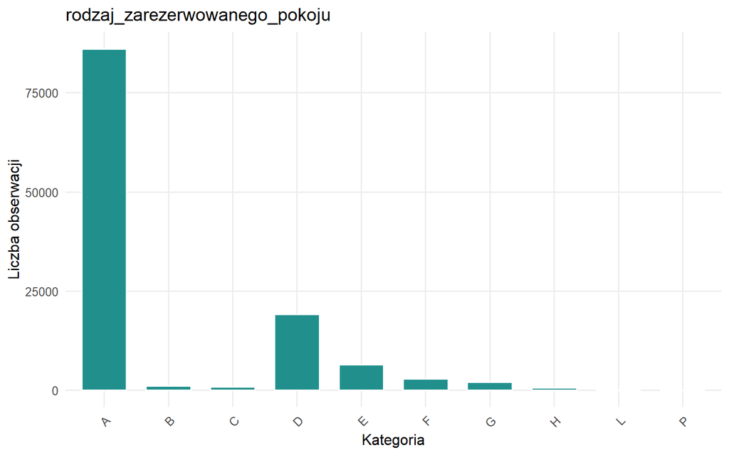

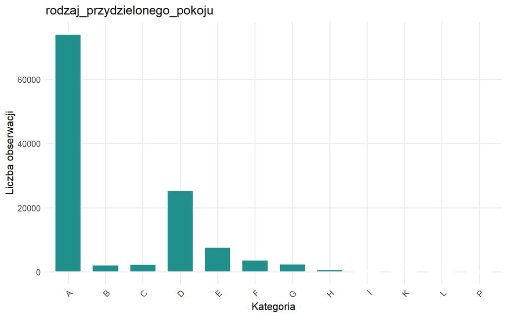

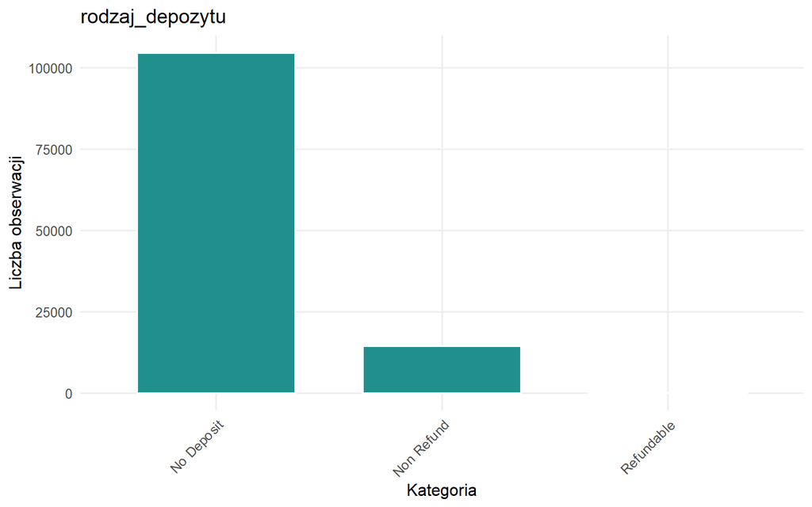

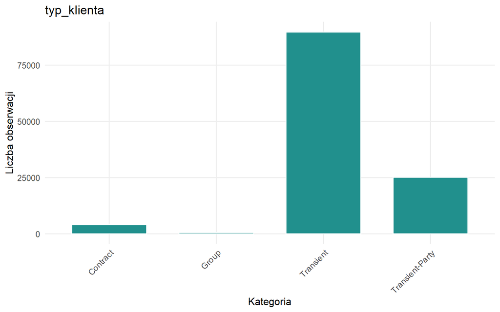

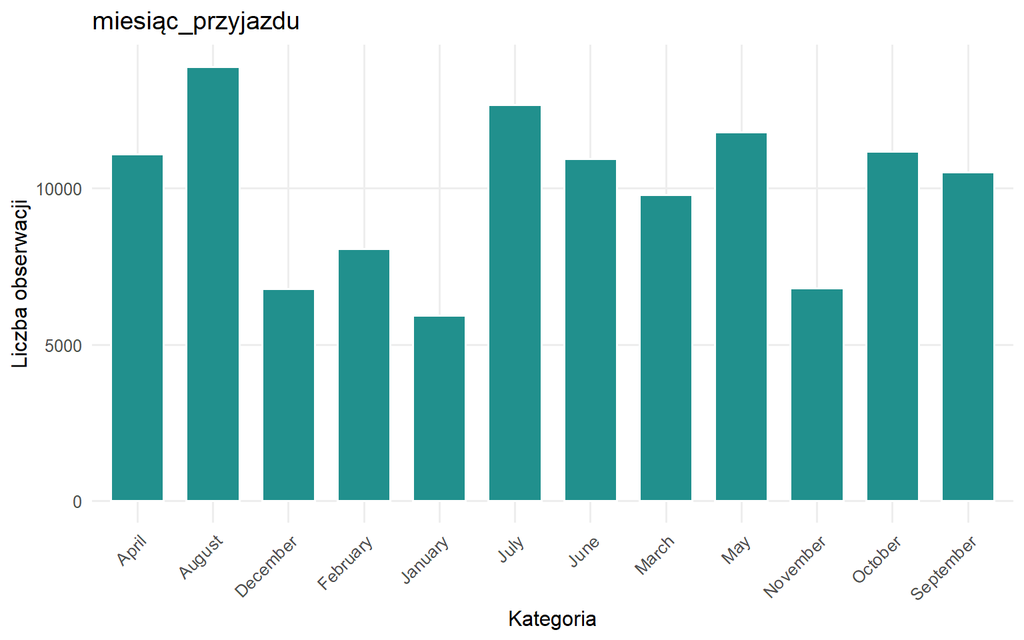

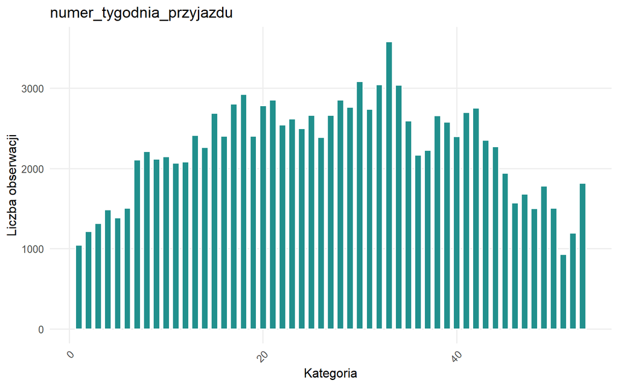

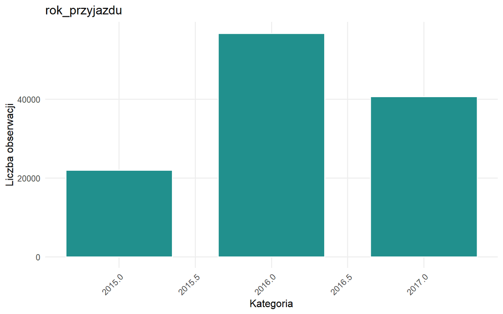

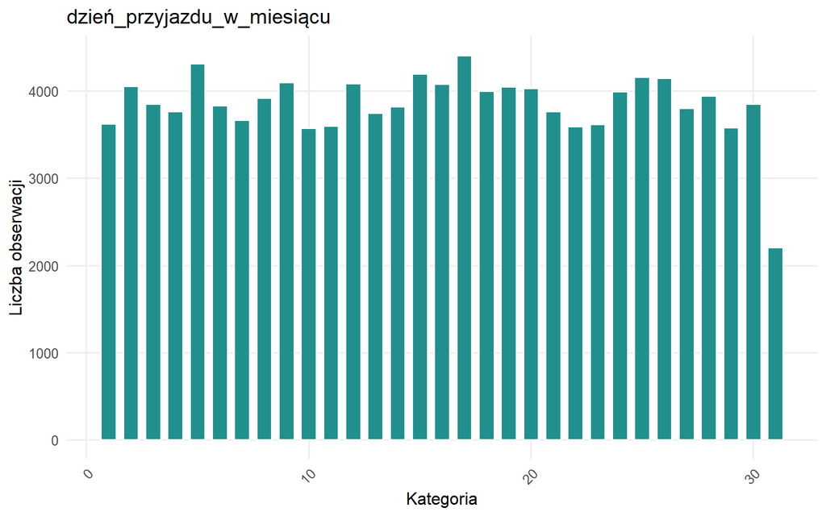

[1 more figures not shown]

## 2.3. Analiza korelacji

Analizę korelacji przeprowadzono dla następujących zmiennych ilościowych oraz dla zmiennej objaśnianej:

1. wcześniejsze_rezerwacje_nieodwołane,
2. liczba_specjalnych_próśb,
3. liczba_nocy_weekendowych,
4. liczba_nocy_tygodniowych,
5. liczba_dorosłych,
6. liczba_dzieci,
7. liczba_niemowląt,
8. wymagane_miejsca_parkingowe,
9. czas_wyprzedzenia_rezerwacji,
10. wcześniejsze_odwołania,
11. liczba_zmian_rezerwacji,
12. liczba_dni_na_liście_oczekujących,
13. średnia_cena_za_noc,
14. powracający_gość,
15. odwołanie_rezerwacji.

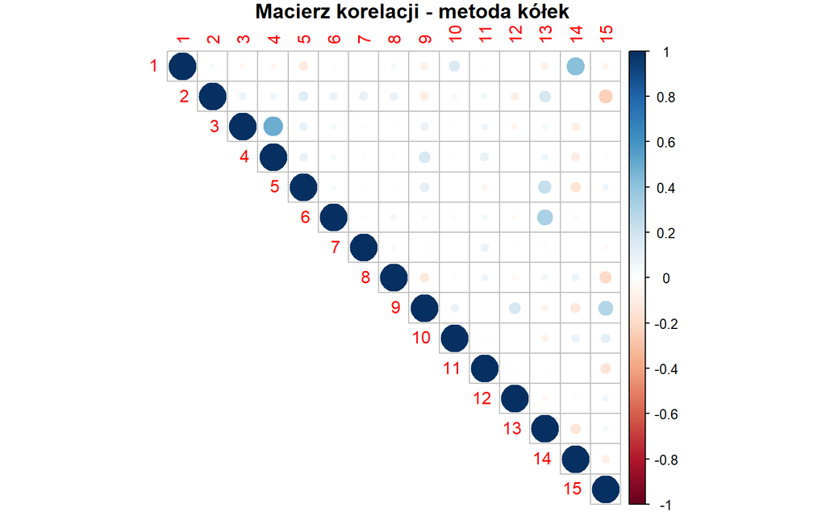

Łatwo zauważyć, że wśród analizowanych zmiennych nie występuje wiele silnych zależności. Największą zależność dodatnią widać między *liczbą nocy weekendowych* oraz *liczbą nocy tygodniowych*. Z kolei najbardziej zauważalna zależność ujemna występuje między *liczbą specjalnych próśb* a *zmienną objaśnianą*. Kolejne zauważalne relacje występują głównie przy zmiennej objaśnianej. Poniżej przeprowadzono szczegółową analizę korelacji.

### 2.3.1. Testy istotności korelacji

H0: Nie istnieje istotna statystycznie korelacja pomiędzy porównywanymi zmiennymi (r = 0).  
HA: Istnieje istotna statystycznie korelacja pomiędzy porównywanymi zmiennymi (r ≠ 0).

1. Test istotności korelacji zmiennych *liczba_nocy_weekendowych* oraz *liczba_nocy_tygodniowych*:

**r = 0.499**

**p-value = 0**

Współczynnik korelacji r = 0.499 wskazuje na umiarkowaną dodatnią zależność między zmiennymi. Bardzo niska wartość p-value (≈ 0) pozwala odrzucić hipotezę zerową, co oznacza, że dłuższe pobyty obejmujące weekend częściej wiążą się również z większą liczbą nocy w dni robocze.

2. Test istotności korelacji zmiennych *liczba_specjalnych_próśb* oraz *odwołanie_rezerwacji*:

r = -0.235

p-value = 0

Ujemna korelacja (r = -0.235) oznacza słabą, lecz istotną zależność – im więcej specjalnych próśb, tym mniejsze prawdopodobieństwo odwołania rezerwacji. Wartość p-value ≈ 0 potwierdza istotność statystyczną tej relacji.

3. Test istotności korelacji zmiennych *wymagane_miejsca_parkingowe* oraz *odwołanie_rezerwacji*:

r = -0.195

p-value = 0

Wartość r = -0.195 wskazuje na słabą ujemną korelację. Istotne statystycznie p-value sugeruje, że klienci wymagający miejsc parkingowych rzadziej odwołują rezerwacje.

4. Test istotności korelacji zmiennych *czas_wyprzedzenia_rezerwacji* oraz *odwołanie_rezerwacji*:

r = 0.293

p-value = 0

Dodatnia korelacja r = 0.293 oznacza słabą do umiarkowanej zależność – im wcześniejsza rezerwacja, tym większe prawdopodobieństwo jej odwołania. Niska wartość p-value potwierdza istotność statystyczną wyniku.

5. Test istotności korelacji zmiennych *wcześniejsze_odwołania* oraz *odwołanie_rezerwacji*:

r = 0.11

p-value = 0

Współczynnik r = 0.11 wskazuje na bardzo słabą, lecz dodatnią zależność. Pomimo niskiej siły korelacji, wynik jest istotny statystycznie, co sugeruje, że klienci z historią odwołań nieznacznie częściej anulują kolejne rezerwacje.

6. Test istotności korelacji zmiennych *liczba_zmian_rezerwacji* oraz *odwołanie_rezerwacji*:

r = -0.144

p-value = 0

Ujemna korelacja r = -0.144 wskazuje na słabą zależność – większa liczba zmian rezerwacji wiąże się z mniejszym prawdopodobieństwem jej odwołania. Istotność statystyczna potwierdzona niskim p-value.

7. Test istotności korelacji zmiennych *powracający_gość* oraz *odwołanie_rezerwacji*:

r = -0.085

p-value = 0

Bardzo słaba ujemna korelacja (r = -0.085) wskazuje, że powracający goście nieco rzadziej odwołują rezerwacje. Mimo niewielkiej siły zależności, wynik jest istotny statystycznie.

*Analiza korelacji* wykazała, że wszystkie badane zależności są istotne statystycznie (p < 0,05), jednak w większości przypadków mają one słabą siłę. Najsilniejszą, umiarkowaną dodatnią korelację zaobserwowano pomiędzy *liczbą nocy weekendowych* i *tygodniowych* (r = 0,499). Pozostałe zmienne wykazują jedynie słabe lub bardzo słabe związki z odwołaniem rezerwacji, co oznacza, że choć zależności te są statystycznie istotne, ich znaczenie praktyczne jest ograniczone.

## 2.4. Analiza braków danych

| Zmienna | Liczba_NA |
| --- | --- |
| typ_hotelu | 0 |
| odwołanie_rezerwacji | 0 |
| czas_wyprzedzenia_rezerwacji | 0 |
| rok_przyjazdu | 0 |
| miesiąc_przyjazdu | 0 |
| numer_tygodnia_przyjazdu | 0 |
| dzień_przyjazdu_w_miesiącu | 0 |
| liczba_nocy_weekendowych | 0 |
| liczba_nocy_tygodniowych | 0 |
| liczba_dorosłych | 0 |

[output cut: 26 more lines]

Analiza braków wykazała, że występują one w trzech zmiennych:

- *liczba_dzieci* (4 braki),
- *firma* (112 593 braków),
- *agent_rezerwacji* (16 340 braków).

| Zmienna | Procent_NA |
| --- | --- |
| liczba_dzieci | 0.003350364352123293 |
| firma | 94.30689337465449 |
| agent_rezerwacji | 13.68623837842365 |

Wartości NA stanowią:

- mniej niż 1% obserwacji zmiennej *liczba_dzieci*,
- blisko 100% wartości zmiennej *firma*,
- niecałe 14% obserwacji zmiennej *agent_rezerwacji*.

W dalszej części pracy zostanie omówione podejście do ich uzupełnienia oraz odpowiednia „obróbka” braków danych, uwzględniająca charakter poszczególnych zmiennych i wpływ na analizę.

## 2.5. Analiza obserwacji odstających

Analiza obserwacji odstających została przeprowadzona dla zmiennych ilościowych.

### 2.5.1 Wykresy pudełkowe ze standaryzacją

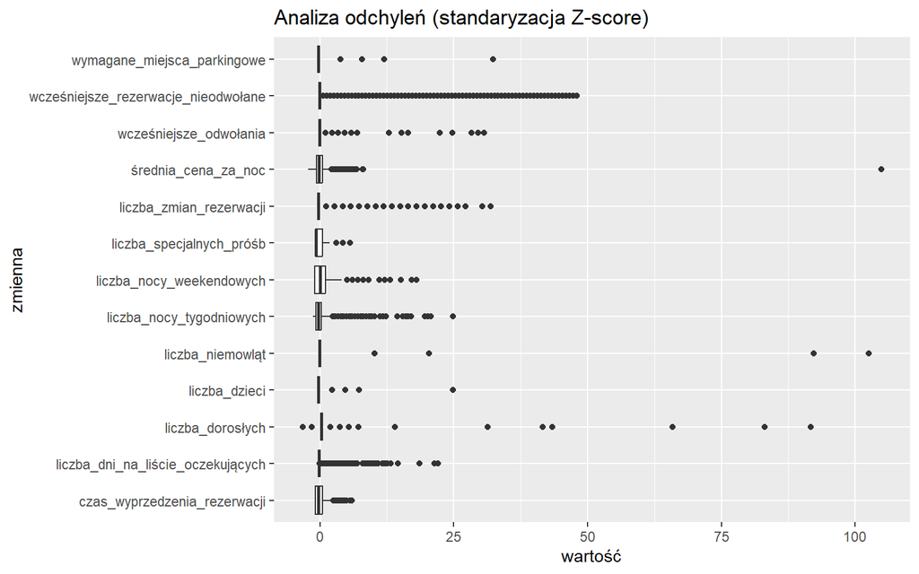

Ogólna analiza odchyleń przy wykorzystaniu boxplotów pokazuje, w których zmiennych ilościowych występują wartości odstające. Poniżej przeprowadzona zostanie szczegółowa analiza odchyleń za pomocą wykresów kwantyl-kwantyl.

### 2.5.2. Wykresy kwantyl-kwantyl z określeniem skośności i kurtozy

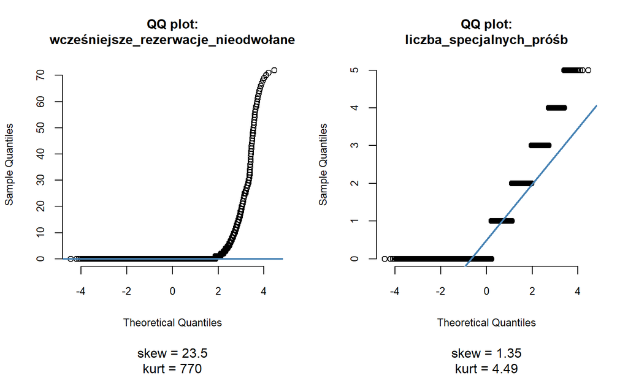

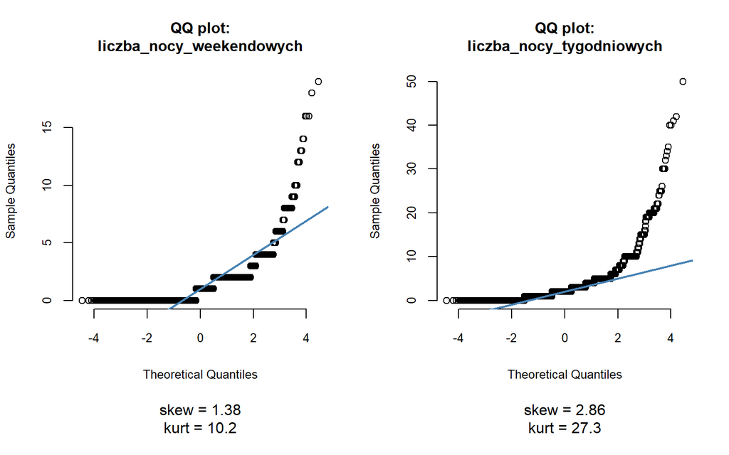

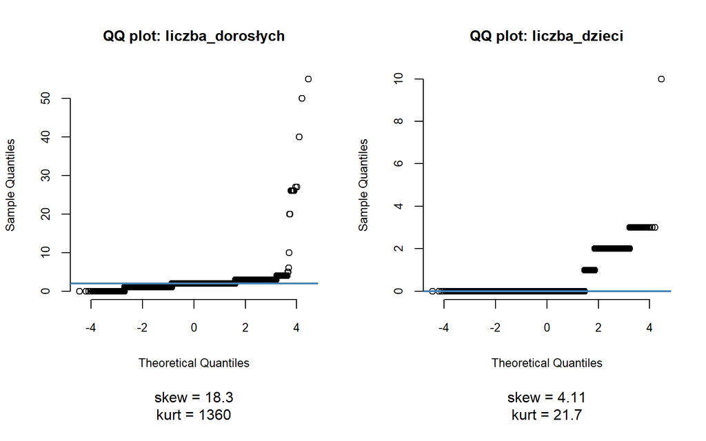

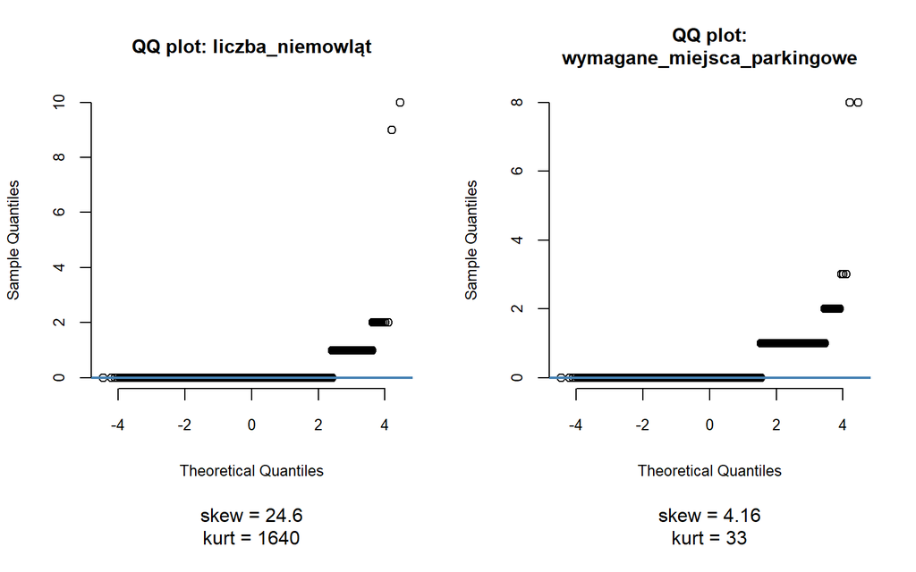